# Bayesian Analysis of GHG Fluxes in Seasonal Wetlands

## 6c. Model 3d — CH₄ with organic carbon predictor *(NEW)*

> **Motivation:** Organic carbon is the primary substrate for **methanogenesis** — the strictly anaerobic pathway that produces CH₄. High C% soils can sustain higher CH₄ production rates independently of current temperature, because the substrate pool is already in place. Replacing temperature with C% therefore targets a more mechanistically direct driver of CH₄ emission.

> **Formula:** `log(fch4+5) ~ swc_s + C + hand + (1|area) + (1|point2) + (1|month)`

> Linear SWC term — simpler and more interpretable than a spline here, where the main question is whether organic carbon explains CH₄ variation beyond the hydro-topographic gradient.

```r
# ── NEW (6c): CH₄ linear model with organic carbon replacing temperature ─────────
mod_ch4_C_path <- "Data/mod_ch4_C_linear.rds"

if (file.exists(mod_ch4_C_path)) {
  mod_ch4_C <- readRDS(mod_ch4_C_path)
} else {
  mod_ch4_C <- brm(
    log_fch4 ~ swc_s + C_s + hand_s +
               (1 | area) + (1 | point2) + (1 | month),
    data    = df_an %>% drop_na(C_s),
    family  = gaussian(),
    prior   = c(prior(normal(0, 1),   class = "b"),
                prior(normal(0, 2),   class = "Intercept"),
                prior(exponential(1), class = "sd"),
                prior(exponential(1), class = "sigma")),
    iter    = 4000,
    warmup  = 1000,
    chains  = 4,
    cores   = 4,
    seed    = 42,
    control = list(adapt_delta = 0.95)
  )
  saveRDS(mod_ch4_C, mod_ch4_C_path)
}
```

```r
# ── NEW (6c): summary ─────────────────────────────────────────────────────────
cat("n =", nrow(df_an %>% drop_na(C_s)), "observations with soil C data\n")
```

```
## n = 228 observations with soil C data
```

```r
summary(mod_ch4_C)
```

[output not shown]

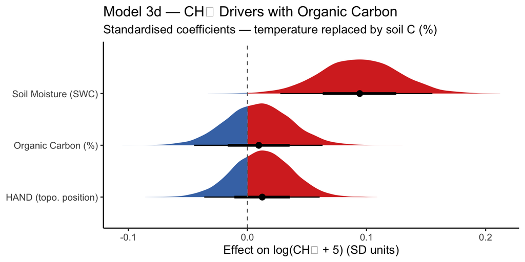

```r
# ── NEW (6c): posterior coefficient plot ──────────────────────────────────────
# swc_s is now a parametric term so it appears in b_ draws alongside C_s & HAND.
post_ch4_C <- as_draws_df(mod_ch4_C) %>%
  select(starts_with("b_")) %>%
  pivot_longer(everything(), names_to = "parameter", values_to = "value") %>%
  filter(parameter != "b_Intercept") %>%
  mutate(parameter = recode(parameter,
    "b_swc_s"  = "Soil Moisture (SWC)",
    "b_C_s"    = "Organic Carbon (%)",
    "b_hand_s" = "HAND (topo. position)"
  ))

ggplot(post_ch4_C, aes(x = value, y = parameter, fill = after_stat(x > 0))) +
  stat_halfeye(.width = c(0.66, 0.95), point_interval = median_hdi) +
  geom_vline(xintercept = 0, linetype = "dashed", colour = "grey40") +
  scale_fill_manual(values = c("#4575b4","#d73027"), guide = "none") +
  labs(title    = "Model 3d — CH₄ Drivers with Organic Carbon",
       subtitle = "Standardised coefficients — temperature replaced by soil C (%)",
       x = "Effect on log(CH₄ + 5) (SD units)", y = NULL) +
  theme_classic(base_size = 13)
```

```r
ggsave("Plots/Bayes_M3d_CH4_Carbon_coef.pdf", width = 8, height = 4)
```

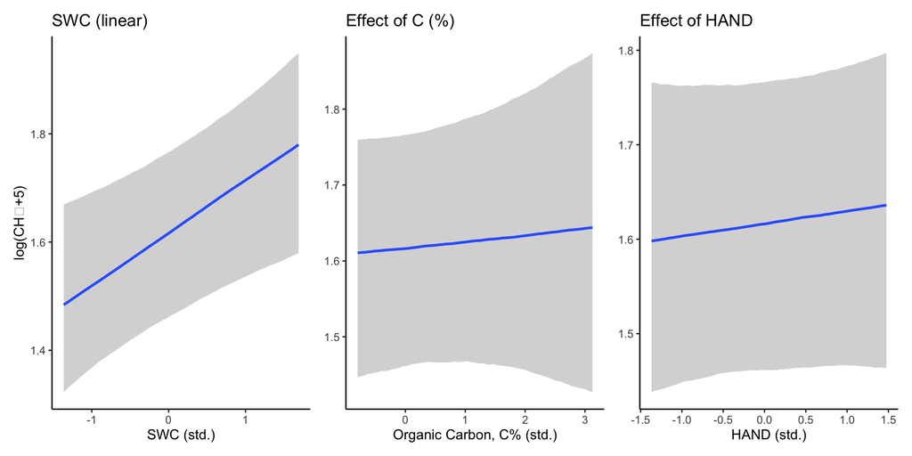

```r
# ── NEW (6c): conditional effects — linear SWC + carbon + HAND ────────────────
ce_ch4_C <- conditional_effects(mod_ch4_C,
                                 effects    = c("swc_s","C_s","hand_s"),
                                 re_formula = NA)

p_swc_ch4_c  <- plot(ce_ch4_C, plot = FALSE)[[1]] +
  labs(x = "SWC (std.)", y = "log(CH₄+5)", title = "SWC (linear)") +
  theme_classic()
p_C_ch4_c    <- plot(ce_ch4_C, plot = FALSE)[[2]] +
  labs(x = "Organic Carbon, C% (std.)", y = NULL, title = "Effect of C (%)") +
  theme_classic()
p_hand_ch4_c <- plot(ce_ch4_C, plot = FALSE)[[3]] +
  labs(x = "HAND (std.)", y = NULL, title = "Effect of HAND") +
  theme_classic()

p_swc_ch4_c + p_C_ch4_c + p_hand_ch4_c
```

```r
ggsave("Plots/Bayes_M3d_CH4_Carbon_CE.pdf", width = 10, height = 4)
```

## 6d. Model 3e — CH₄ Gamma regression *(NEW)*

> **Why Gamma regression for CH₄?** Same motivation as section 5d for CO₂. The current models apply Gaussian family to **log(fch4 + 5)**, which works but hides predictions behind a log scale and assumes constant variance on that scale.

> CH₄ presents an extra complication: raw fluxes can be negative (net CH₄ uptake by the soil), so a strict positivity requirement must be satisfied before fitting Gamma. We use `fch4_pos = fch4 + 5` (already added to df_an), which shifts all values into positive territory. We additionally verify no values remain ≤ 0.

> **Formula:** `fch4_pos ~ swc_s + ts + hand + (1|area) + (1|point2) + (1|month)`

> Linear SWC term; Gamma with log link replaces Gaussian on the log-transformed response. All coefficients are on the log scale — exp(b) gives fold changes in CH₄ + 5.

```r
# ── NEW (6d): CH₄ Gamma regression with linear SWC ────────────────────────────
# Verify all fch4_pos values are strictly positive before fitting
stopifnot(all(df_an$fch4_pos > 0, na.rm = TRUE))

mod_ch4_gamma_path <- "Data/mod_ch4_gamma_linear.rds"

if (file.exists(mod_ch4_gamma_path)) {
  mod_ch4_gamma <- readRDS(mod_ch4_gamma_path)
} else {
  mod_ch4_gamma <- brm(
    fch4_pos ~ swc_s + ts_s + hand_s +
               (1 | area) + (1 | point2) + (1 | month),
    data    = df_an,
    family  = Gamma(link = "log"),
    prior   = c(prior(normal(0, 1),   class = "b"),
                prior(normal(2, 2),   class = "Intercept"),  # log(fch4+5) ≈ 1-3
                prior(exponential(1), class = "sd"),
                prior(exponential(1), class = "shape")),
    iter    = 4000,
    warmup  = 1000,
    chains  = 4,
    cores   = 4,
    seed    = 42,
    control = list(adapt_delta = 0.95)
  )
  saveRDS(mod_ch4_gamma, mod_ch4_gamma_path)
}
```

```r
# ── NEW (6d): summary ─────────────────────────────────────────────────────────
summary(mod_ch4_gamma)
```

```
##  Family: gamma
##   Links: mu = log; shape = identity
## Formula: fch4_pos ~ swc_s + ts_s + hand_s + (1 | area) + (1 | point2) + (1 | month)
##    Data: df_an (Number of observations: 228)
##   Draws: 4 chains, each with iter = 4000; warmup = 1000; thin = 1;
##          total post-warmup draws = 12000
##
## Multilevel Hyperparameters:
## ~area (Number of levels: 5)
##               Estimate Est.Error l-95% CI u-95% CI Rhat Bulk_ESS Tail_ESS
## sd(Intercept)     0.04      0.04     0.00     0.15 1.00     4424     5528
##
## ~month (Number of levels: 6)
##               Estimate Est.Error l-95% CI u-95% CI Rhat Bulk_ESS Tail_ESS
## sd(Intercept)     0.16      0.08     0.06     0.36 1.00     3890     6210
##
## ~point2 (Number of levels: 46)
##               Estimate Est.Error l-95% CI u-95% CI Rhat Bulk_ESS Tail_ESS
## sd(Intercept)     0.07      0.03     0.01     0.13 1.00     3126     3952
##
## Regression Coefficients:
##           Estimate Est.Error l-95% CI u-95% CI Rhat Bulk_ESS Tail_ESS
## Intercept     1.64      0.08     1.48     1.80 1.00     3228     4213
## swc_s         0.09      0.03     0.03     0.15 1.00     6529     8308
## ts_s          0.01      0.03    -0.04     0.07 1.00    11740     9356
## hand_s       -0.01      0.03    -0.06     0.04 1.00     8110     7981
##
## Further Distributional Parameters:
##       Estimate Est.Error l-95% CI u-95% CI Rhat Bulk_ESS Tail_ESS
## shape    14.10      1.47    11.39    17.15 1.00     8748     9054
##
## Draws were sampled using sampling(NUTS). For each parameter, Bulk_ESS
## and Tail_ESS are effective sample size measures, and Rhat is the potential
## scale reduction factor on split chains (at convergence, Rhat = 1).
```

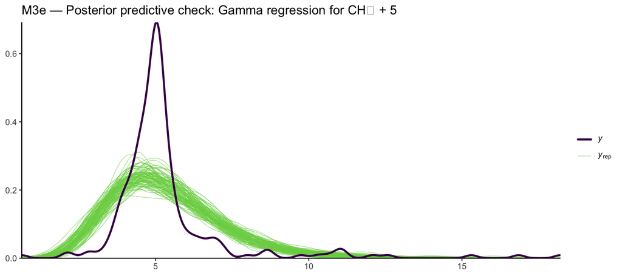

```r
# ── NEW (6d): pp_check — compare to log-Gaussian (M3c) visually ──────────────
# If Gamma simulated draws track the observed right-skewed CH₄ distribution
# more closely than the log-Gaussian, it is the better-calibrated model.
pp_check(mod_ch4_gamma, ndraws = 100) +
  ggtitle("M3e — Posterior predictive check: Gamma regression for CH₄ + 5") +
  theme_classic()
```

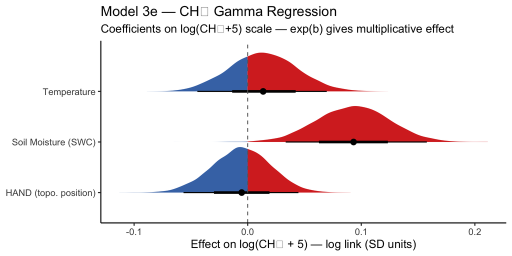

```r
# ── NEW (6d): posterior coefficient plot ──────────────────────────────────────
# swc_s is now parametric so it appears alongside ts_s and hand_s in b_ draws.
post_ch4_gamma <- as_draws_df(mod_ch4_gamma) %>%
  select(starts_with("b_")) %>%
  pivot_longer(everything(), names_to = "parameter", values_to = "value") %>%
  filter(parameter != "b_Intercept") %>%
  mutate(parameter = recode(parameter,
    "b_swc_s"  = "Soil Moisture (SWC)",
    "b_ts_s"   = "Temperature",
    "b_hand_s" = "HAND (topo. position)"
  ))

ggplot(post_ch4_gamma, aes(x = value, y = parameter, fill = after_stat(x > 0))) +
  stat_halfeye(.width = c(0.66, 0.95), point_interval = median_hdi) +
  geom_vline(xintercept = 0, linetype = "dashed", colour = "grey40") +
  scale_fill_manual(values = c("#4575b4","#d73027"), guide = "none") +
  labs(title    = "Model 3e — CH₄ Gamma Regression",
       subtitle = "Coefficients on log(CH₄+5) scale — exp(b) gives multiplicative effect",
       x = "Effect on log(CH₄ + 5) — log link (SD units)", y = NULL) +
  theme_classic(base_size = 13)
```

```r
ggsave("Plots/Bayes_M3e_CH4_Gamma_coef.pdf", width = 8, height = 4)
```

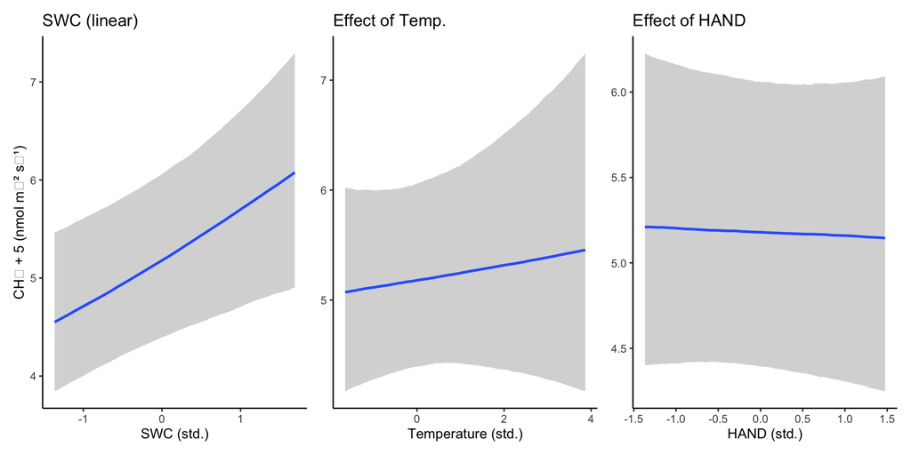

```r
# ── NEW (6d): conditional effects on the original (CH₄ + 5) scale ─────────────
# Subtract 5 from y-axis labels mentally to read as true CH₄ flux.
ce_ch4_gamma <- conditional_effects(mod_ch4_gamma,
                                     effects    = c("swc_s","ts_s","hand_s"),
                                     re_formula = NA)

p_swc_ge  <- plot(ce_ch4_gamma, plot = FALSE)[[1]] +
  labs(x = "SWC (std.)", y = "CH₄ + 5 (nmol m⁻² s⁻¹)", title = "SWC (linear)") +
  theme_classic()
p_ts_ge   <- plot(ce_ch4_gamma, plot = FALSE)[[2]] +
  labs(x = "Temperature (std.)", y = NULL, title = "Effect of Temp.") +
  theme_classic()
p_hand_ge <- plot(ce_ch4_gamma, plot = FALSE)[[3]] +
  labs(x = "HAND (std.)", y = NULL, title = "Effect of HAND") +
  theme_classic()

p_swc_ge + p_ts_ge + p_hand_ge
```

```r
ggsave("Plots/Bayes_M3e_CH4_Gamma_CE.pdf", width = 10, height = 4)
```

> **Note on model comparison:** As with CO₂, LOO-CV cannot compare M3c (Gaussian on log-transformed response) directly with M3e (Gamma on raw shifted response) because the response variables differ. Judge fit using pp_check. If M3e’s simulated distributions better replicate the heavy right tail of CH₄ + 5, prefer Gamma for final reporting.

## 6e. Model 3f — Hurdle Gamma for CH₄ *(NEW)*

### Why a hurdle model?

The pp_check of M3e (Gamma regression) revealed a fundamental mismatch: the observed CH₄ + 5 distribution has a **sharp spike at x = 5** (i.e. raw fch₄ ≈ 0) followed by a long right tail, while the Gamma posterior predictive draws produce a smooth unimodal curve that cannot reproduce the spike at all.

This pattern is not a modelling artefact — it reflects a genuine **two-state biological process** in seasonal wetlands:

**State 1 — aerobic / non-emitting (the spike).** When soils are dry (typically dry-season campaigns: set24, jun25, set25) there is sufficient oxygen in the pore space to suppress methanogenesis completely. CH₄ flux measurements at these points are zero or slightly negative (net uptake by methanotrophic bacteria oxidising atmospheric CH₄). These observations carry no information about methanogenesis — they are structurally zero.

**State 2 — anaerobic / emitting (the tail).** When soils are saturated (wet-season campaigns: nov24, fev25, dez25) oxygen is excluded, anaerobic microsites proliferate, and methanogens become active. CH₄ flux is now a genuinely positive, right-skewed quantity driven by substrate availability (organic carbon), temperature, and the depth of the water table (indexed by HAND).

A single Gamma (or lognormal) distribution tries to fit both states with one curve — an impossible task when one state is a point mass at zero and the other is a continuous right-skewed distribution. The `+5` offset made this worse by physically shifting the zero-mass to x = 5, which is why the Gamma spike appeared there rather than at zero.

### The hurdle Gamma solution

A **hurdle model** (also called a two-part model) handles this by splitting the likelihood into two explicitly separate components:

1. **Hurdle component** — a logistic regression for the binary outcome *“does this observation belong to the zero (aerobic) state?”* Predictors: SWC and HAND are the primary drivers of whether a soil is aerobic or anaerobic; month captures remaining seasonal structure.
2. **Positive component** — a Gamma regression (log link) fitted **only to the non-zero observations**, modelling how much CH₄ is emitted once the anaerobic threshold is crossed. Predictors: SWC, temperature, HAND, and the full hierarchical random effects.

The two sub-models are estimated jointly in a single MCMC run, so uncertainty propagates correctly between them.

> **Variable used:** `fch4_hurdle = if_else(fch4 ≤ 0, 0, fch4)` — raw CH₄ flux with all non-positive values set to exactly 0. This directly encodes the ecological interpretation: fch4 ≤ 0 means “no net CH₄ emission” (aerobic or uptake state); fch4 > 0 means “active methanogenesis”. No arbitrary offset needed — the hurdle handles the zeros natively.

**Formula:**

```
fch4_hurdle ~ swc_s + ts_s + hand_s + (1|area) + (1|point2) + (1|month)   # positive part
hu           ~ swc_s + hand_s + (1|area) + (1|month)                       # P(zero state)
```

`hu` is the probability of being in the **zero (aerobic) state** on the logit scale. A **negative** coefficient on `swc_s` for `hu` means higher soil moisture → lower probability of zero → more likely to emit CH₄, which is the ecologically expected direction.

```r
# ── NEW (6e): Hurdle Gamma model for CH₄ ──────────────────────────────────────
# fch4_hurdle = 0  → aerobic / non-emitting state  (modelled by 'hu' logistic)
# fch4_hurdle > 0  → active methanogenesis          (modelled by Gamma log-link)
#
# The two sub-models share the same MCMC run; priors are specified per sub-model
# using the dpar argument.

prior_hurdle <- c(
  # ── positive (Gamma) component ────────────────────────────────────────────
  prior(normal(0, 1),   class = "b"),
  prior(normal(1, 2),   class = "Intercept"),    # log(fch4) for positive obs
  prior(exponential(1), class = "sd"),
  prior(exponential(1), class = "shape"),
  # ── hurdle (logistic) component — use dpar = "hu" ─────────────────────────
  prior(normal(0, 1),   class = "b",         dpar = "hu"),
  prior(normal(0, 1.5), class = "Intercept", dpar = "hu"),  # logit scale
  prior(exponential(1), class = "sd",        dpar = "hu")
)

mod_ch4_hurdle_path <- "Data/mod_ch4_hurdle.rds"

if (file.exists(mod_ch4_hurdle_path)) {
  mod_ch4_hurdle <- readRDS(mod_ch4_hurdle_path)
} else {
  mod_ch4_hurdle <- brm(
    bf(
      # positive component: how much CH₄ when emitting?
      fch4_hurdle ~ swc_s + ts_s + hand_s +
                    (1 | area) + (1 | point2) + (1 | month),
      # hurdle component: P(zero / aerobic state)
      hu          ~ swc_s + hand_s + (1 | area) + (1 | month)
    ),
    data    = df_an,
    family  = hurdle_gamma(link = "log", link_hu = "logit"),
    prior   = prior_hurdle,
    iter    = 4000,
    warmup  = 1000,
    chains  = 4,
    cores   = 4,
    seed    = 42,
    control = list(adapt_delta = 0.97)   # hurdle models can have higher curvature
  )
  saveRDS(mod_ch4_hurdle, mod_ch4_hurdle_path)
}
```

```r
# ── NEW (6e): summary ─────────────────────────────────────────────────────────
# Two blocks appear:
#   Regression Coefficients            → positive (Gamma) component, log scale
#   Regression Coefficients (hu)       → hurdle (logistic) component, logit scale
# A negative hu coefficient on swc_s means more moisture = less likely zero = more CH₄
summary(mod_ch4_hurdle)
```

```
##  Family: hurdle_gamma
##   Links: mu = log; shape = identity; hu = logit
## Formula: fch4_hurdle ~ swc_s + ts_s + hand_s + (1 | area) + (1 | point2) + (1 | month)
##          hu ~ swc_s + hand_s + (1 | area) + (1 | month)
##    Data: df_an (Number of observations: 228)
##   Draws: 4 chains, each with iter = 4000; warmup = 1000; thin = 1;
##          total post-warmup draws = 12000
##
## Multilevel Hyperparameters:
## ~area (Number of levels: 5)
##                  Estimate Est.Error l-95% CI u-95% CI Rhat Bulk_ESS Tail_ESS
## sd(Intercept)        0.37      0.30     0.02     1.11 1.00     4530     6476
## sd(hu_Intercept)     0.24      0.23     0.01     0.84 1.00     7403     6788
##
## ~month (Number of levels: 6)
##                  Estimate Est.Error l-95% CI u-95% CI Rhat Bulk_ESS Tail_ESS
## sd(Intercept)        0.76      0.36     0.29     1.64 1.00     6020     6503
## sd(hu_Intercept)     1.19      0.48     0.52     2.34 1.00     6560     7902
##
## ~point2 (Number of levels: 46)
##               Estimate Est.Error l-95% CI u-95% CI Rhat Bulk_ESS Tail_ESS
## sd(Intercept)     0.74      0.21     0.31     1.16 1.00     3182     3144
##
## Regression Coefficients:
##              Estimate Est.Error l-95% CI u-95% CI Rhat Bulk_ESS Tail_ESS
## Intercept       -0.32      0.44    -1.20     0.58 1.00     7206     7254
## hu_Intercept     0.08      0.52    -0.94     1.15 1.00     7082     7782
## swc_s            0.03      0.23    -0.43     0.46 1.00     7950     8774
## ts_s             0.23      0.22    -0.21     0.65 1.00    12310     8842
## hand_s          -0.49      0.21    -0.90    -0.08 1.00     9118     9456
## hu_swc_s        -1.23      0.26    -1.75    -0.72 1.00    13359     9818
## hu_hand_s       -0.47      0.21    -0.89    -0.07 1.00    15017     9304
##
## Further Distributional Parameters:
##       Estimate Est.Error l-95% CI u-95% CI Rhat Bulk_ESS Tail_ESS
## shape     0.75      0.10     0.56     0.96 1.00     6373     7765
##
## Draws were sampled using sampling(NUTS). For each parameter, Bulk_ESS
## and Tail_ESS are effective sample size measures, and Rhat is the potential
## scale reduction factor on split chains (at convergence, Rhat = 1).
```

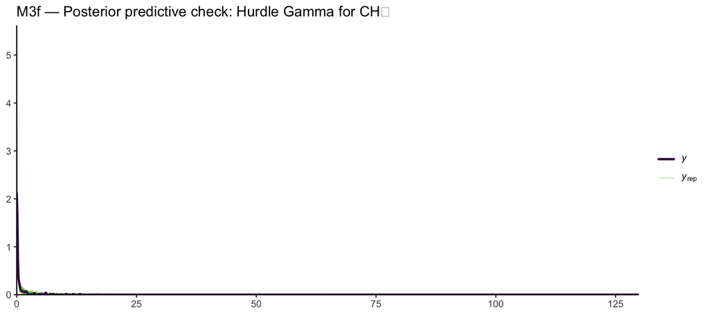

```r
# ── NEW (6e): pp_check — should now capture the spike + tail structure ─────────
# If successful, the green draws will show the spike near zero AND the right tail.
pp_check(mod_ch4_hurdle, ndraws = 100) +
  ggtitle("M3f — Posterior predictive check: Hurdle Gamma for CH₄") +
  theme_classic()
```

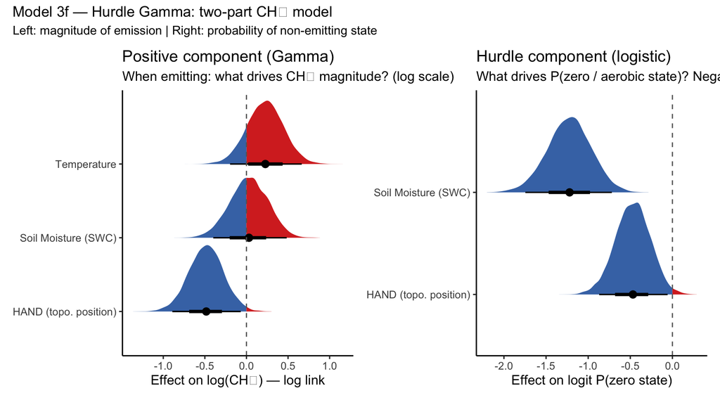

```r
# ── NEW (6e): coefficient plots — one panel per sub-model ─────────────────────

# ── Positive (Gamma) component: how much CH₄ when emitting? ──────────────────
post_hurdle_pos <- as_draws_df(mod_ch4_hurdle) %>%
  select(starts_with("b_") & !starts_with("b_hu_")) %>%
  pivot_longer(everything(), names_to = "parameter", values_to = "value") %>%
  filter(parameter != "b_Intercept") %>%
  mutate(parameter = recode(parameter,
    "b_swc_s"  = "Soil Moisture (SWC)",
    "b_ts_s"   = "Temperature",
    "b_hand_s" = "HAND (topo. position)"
  ))

p_pos <- ggplot(post_hurdle_pos,
                aes(x = value, y = parameter, fill = after_stat(x > 0))) +
  stat_halfeye(.width = c(0.66, 0.95), point_interval = median_hdi) +
  geom_vline(xintercept = 0, linetype = "dashed", colour = "grey40") +
  scale_fill_manual(values = c("#4575b4","#d73027"), guide = "none") +
  labs(title    = "Positive component (Gamma)",
       subtitle = "When emitting: what drives CH₄ magnitude? (log scale)",
       x = "Effect on log(CH₄) — log link", y = NULL) +
  theme_classic(base_size = 12)

# ── Hurdle (logistic) component: what drives the zero state? ─────────────────
# Negative coefficient = predictor REDUCES probability of being zero
# i.e., promotes active CH₄ emission
post_hurdle_hu <- as_draws_df(mod_ch4_hurdle) %>%
  select(starts_with("b_hu_")) %>%
  pivot_longer(everything(), names_to = "parameter", values_to = "value") %>%
  filter(parameter != "b_hu_Intercept") %>%
  mutate(parameter = recode(parameter,
    "b_hu_swc_s"  = "Soil Moisture (SWC)",
    "b_hu_hand_s" = "HAND (topo. position)"
  ))

p_hu <- ggplot(post_hurdle_hu,
               aes(x = value, y = parameter, fill = after_stat(x > 0))) +
  stat_halfeye(.width = c(0.66, 0.95), point_interval = median_hdi) +
  geom_vline(xintercept = 0, linetype = "dashed", colour = "grey40") +
  scale_fill_manual(values = c("#4575b4","#d73027"), guide = "none") +
  labs(title    = "Hurdle component (logistic)",
       subtitle = "What drives P(zero / aerobic state)? Negative = promotes emission",
       x = "Effect on logit P(zero state)", y = NULL) +
  theme_classic(base_size = 12)

p_pos + p_hu +
  plot_annotation(
    title    = "Model 3f — Hurdle Gamma: two-part CH₄ model",
    subtitle = "Left: magnitude of emission | Right: probability of non-emitting state"
  )
```

```r
ggsave("Plots/Bayes_M3f_CH4_Hurdle_coef.pdf", width = 9, height = 5)
```

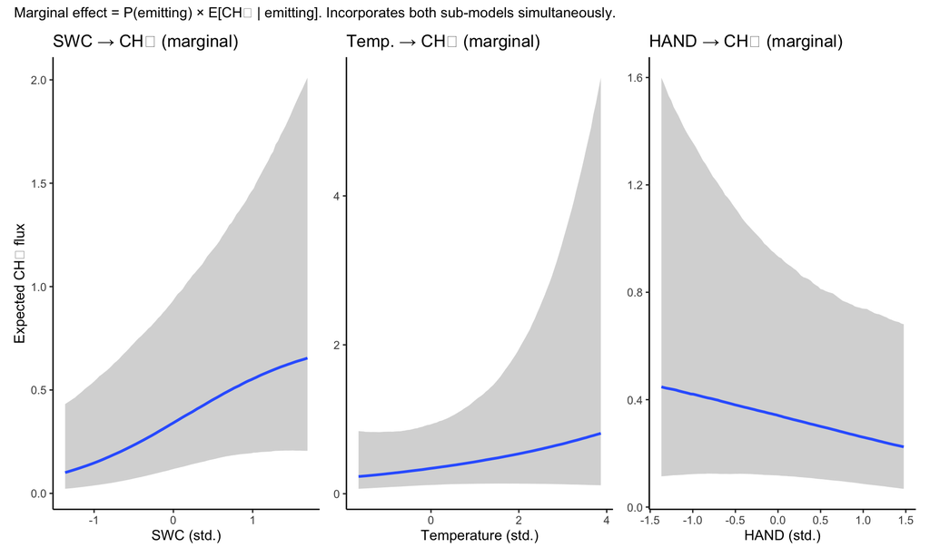

```r
# ── NEW (6e): conditional effects — both components ───────────────────────────
# conditional_effects() for hurdle models returns predictions for the full
# response (integrating over both components) by default, which is the most
# interpretable quantity: E[CH₄] = P(emitting) × E[CH₄ | emitting].

ce_hurdle <- conditional_effects(mod_ch4_hurdle,
                                  effects    = c("swc_s","ts_s","hand_s"),
                                  re_formula = NA)

p_swc_h  <- plot(ce_hurdle, plot = FALSE)[[1]] +
  labs(x = "SWC (std.)", y = "Expected CH₄ flux",
       title = "SWC → CH₄ (marginal)") + theme_classic()
p_ts_h   <- plot(ce_hurdle, plot = FALSE)[[2]] +
  labs(x = "Temperature (std.)", y = NULL,
       title = "Temp. → CH₄ (marginal)") + theme_classic()
p_hand_h <- plot(ce_hurdle, plot = FALSE)[[3]] +
  labs(x = "HAND (std.)", y = NULL,
       title = "HAND → CH₄ (marginal)") + theme_classic()

p_swc_h + p_ts_h + p_hand_h +
  plot_annotation(
    subtitle = paste("Marginal effect = P(emitting) × E[CH₄ | emitting].",
                     "Incorporates both sub-models simultaneously.")
  )
```

```r
ggsave("Plots/Bayes_M3f_CH4_Hurdle_CE.pdf", width = 10, height = 4)
```

## 7. Model 4 — Carbon Content Drivers

**Question:** Is soil carbon content predicted by the same hydro-topographic gradient that drives fluxes?

**Formula:** `C ~ swc + ts + hand + (1|area)`

```r
prior_C <- c(
  prior(normal(0, 1),   class = "b"),
  prior(normal(0, 2),   class = "Intercept"),
  prior(exponential(1), class = "sd"),
  prior(exponential(1), class = "sigma")
)

mod_C_path <- "Data/mod_C.rds"

if (file.exists(mod_C_path)) {
  mod_C <- readRDS(mod_C_path)
} else {
  mod_C <- brm(
    C_s ~ swc_s + ts_s + hand_s + (1 | area),
    data    = df_an %>% drop_na(C),
    family  = gaussian(),
    prior   = prior_C,
    iter    = 4000,
    warmup  = 1000,
    chains  = 4,
    cores   = 4,
    seed    = 42,
    control = list(adapt_delta = 0.95)
  )
  saveRDS(mod_C, mod_C_path)
}
```

```r
summary(mod_C)
```

```
##  Family: gaussian
##   Links: mu = identity; sigma = identity
## Formula: C_s ~ swc_s + ts_s + hand_s + (1 | area)
##    Data: df_an %>% drop_na(C) (Number of observations: 228)
##   Draws: 4 chains, each with iter = 4000; warmup = 1000; thin = 1;
##          total post-warmup draws = 12000
##
## Multilevel Hyperparameters:
## ~area (Number of levels: 5)
##               Estimate Est.Error l-95% CI u-95% CI Rhat Bulk_ESS Tail_ESS
## sd(Intercept)     0.35      0.18     0.13     0.83 1.00     3191     5318
##
## Regression Coefficients:
##           Estimate Est.Error l-95% CI u-95% CI Rhat Bulk_ESS Tail_ESS
## Intercept    -0.01      0.17    -0.38     0.33 1.00     3643     4335
## swc_s         0.38      0.06     0.26     0.50 1.00     7908     7953
## ts_s          0.15      0.06     0.04     0.26 1.00     9524     8224
## hand_s       -0.50      0.05    -0.61    -0.39 1.00     8240     8000
##
## Further Distributional Parameters:
##       Estimate Est.Error l-95% CI u-95% CI Rhat Bulk_ESS Tail_ESS
## sigma     0.71      0.03     0.64     0.78 1.00     9964     8421
##
## Draws were sampled using sampling(NUTS). For each parameter, Bulk_ESS
## and Tail_ESS are effective sample size measures, and Rhat is the potential
## scale reduction factor on split chains (at convergence, Rhat = 1).
```

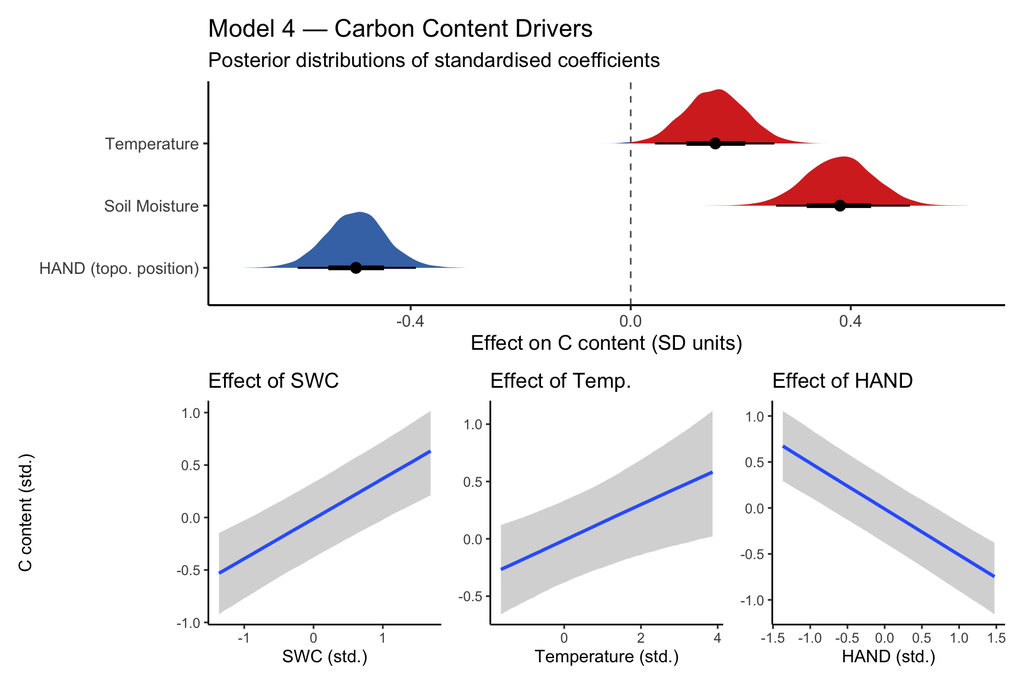

```r
post_C <- as_draws_df(mod_C) %>%
  select(starts_with("b_")) %>%
  pivot_longer(everything(), names_to = "parameter", values_to = "value") %>%
  filter(parameter != "b_Intercept") %>%
  mutate(parameter = recode(parameter,
    "b_swc_s"  = "Soil Moisture",
    "b_ts_s"   = "Temperature",
    "b_hand_s" = "HAND (topo. position)"
  ))

p_C_coef <- ggplot(post_C, aes(x = value, y = parameter, fill = after_stat(x > 0))) +
  stat_halfeye(.width = c(0.66, 0.95), point_interval = median_hdi) +
  geom_vline(xintercept = 0, linetype = "dashed", colour = "grey40") +
  scale_fill_manual(values = c("#4575b4","#d73027"), guide = "none") +
  labs(title    = "Model 4 — Carbon Content Drivers",
       subtitle = "Posterior distributions of standardised coefficients",
       x = "Effect on C content (SD units)", y = NULL) +
  theme_classic(base_size = 13)

ce_C <- conditional_effects(mod_C,
                             effects    = c("swc_s","ts_s","hand_s"),
                             re_formula = NA)

p_swc4  <- plot(ce_C, plot = FALSE)[[1]] +
  labs(x = "SWC (std.)", y = "C content (std.)", title = "Effect of SWC") + theme_classic()
p_ts4   <- plot(ce_C, plot = FALSE)[[2]] +
  labs(x = "Temperature (std.)", y = NULL, title = "Effect of Temp.") + theme_classic()
p_hand4 <- plot(ce_C, plot = FALSE)[[3]] +
  labs(x = "HAND (std.)", y = NULL, title = "Effect of HAND") + theme_classic()

p_C_coef / (p_swc4 + p_ts4 + p_hand4)
```

```r
ggsave("Plots/Bayes_M4_Carbon.pdf", width = 10, height = 8)
```

## 8. Synthesis Plots

### 8a. Unified coefficient comparison — best models

> Models shown: M1 (Gaussian SWC drivers), M2c (CO₂ quadratic + organic carbon), M3f positive component (CH₄ hurdle Gamma — magnitude of emission when active), M4 (carbon content drivers). All predictors are standardised so coefficients are directly comparable within and across panels.

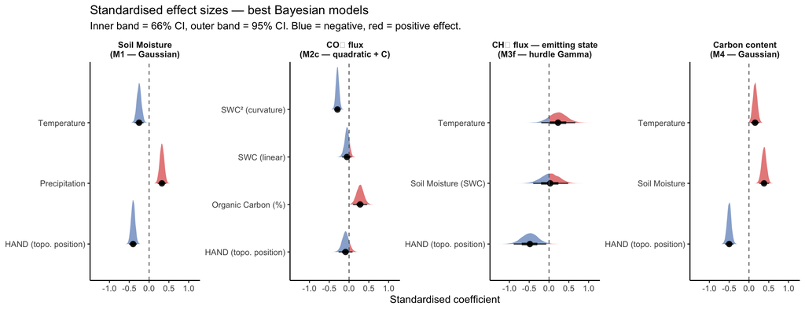

```r
# ── post_hurdle_pos was created in section 6e; represents the Gamma sub-model
# (what drives how much CH₄ is emitted, given the site is in the emitting state)
bind_rows(
  post_swc         %>% mutate(response = "Soil Moisture\n(M1 — Gaussian)"),
  post_co2_C       %>% mutate(response = "CO₂ flux\n(M2c — quadratic + C)"),
  post_hurdle_pos  %>% mutate(response = "CH₄ flux — emitting state\n(M3f — hurdle Gamma)"),
  post_C           %>% mutate(response = "Carbon content\n(M4 — Gaussian)")
) %>%
  mutate(response = factor(response,
           levels = c("Soil Moisture\n(M1 — Gaussian)",
                      "CO₂ flux\n(M2c — quadratic + C)",
                      "CH₄ flux — emitting state\n(M3f — hurdle Gamma)",
                      "Carbon content\n(M4 — Gaussian)"))) %>%
  ggplot(aes(x = value, y = parameter, fill = after_stat(x > 0))) +
  stat_halfeye(.width = c(0.66, 0.95), point_interval = median_hdi,
               alpha = 0.8, slab_alpha = 0.6) +
  geom_vline(xintercept = 0, linetype = "dashed", colour = "grey40") +
  scale_fill_manual(values = c("#4575b4","#d73027"), guide = "none") +
  facet_wrap(~response, nrow = 1, scales = "free_y") +
  labs(title    = "Standardised effect sizes — best Bayesian models",
       subtitle = "Inner band = 66% CI, outer band = 95% CI. Blue = negative, red = positive effect.",
       x = "Standardised coefficient", y = NULL) +
  theme_classic(base_size = 12) +
  theme(strip.background = element_blank(),
        strip.text = element_text(face = "bold", size = 10))
```

```r
ggsave("Plots/Bayes_Synthesis_Coefficients.pdf", width = 13, height = 5)
```

### 8b. The causal chain: topography → moisture → fluxes

> CO₂ curve: M2c (quadratic SWC + organic carbon, C held at mean). CH₄ curve: M3f hurdle Gamma — marginal prediction integrating P(emitting) × E[CH₄ | emitting], which is the quantity directly comparable to field flux measurements.

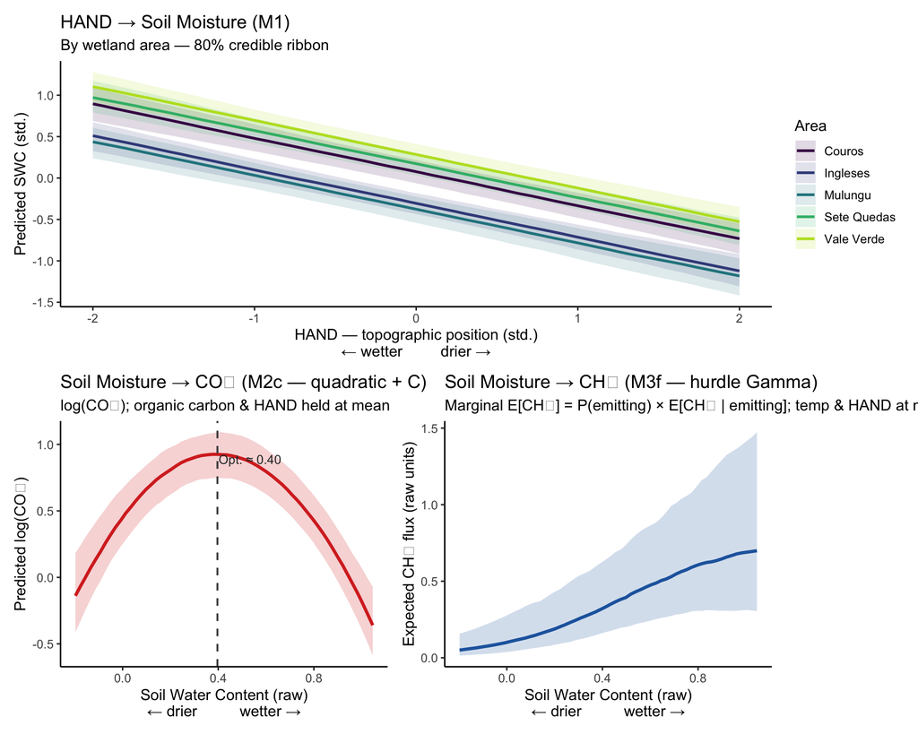

```r
# ── SWC along HAND gradient by area (M1 Gaussian) ─────────────────────────────
hand_seq <- seq(-2, 2, length.out = 60)

pred_swc_area <- expand_grid(
  hand_s = hand_seq,
  ts_s   = 0,
  prec_s = 0,
  area   = unique(df_an$area)
) %>%
  add_epred_draws(mod_swc, ndraws = 500, re_formula = ~(1|area)) %>%
  group_by(hand_s, area) %>%
  summarise(swc_med = median(.epred),
            swc_lo  = quantile(.epred, 0.1),
            swc_hi  = quantile(.epred, 0.9),
            .groups = "drop") %>%
  mutate(area = recode(as.character(area),
    vvt="Vale Verde", bbt="Mulungu", cr="Couros",
    ing="Ingleses",   seteq="Sete Quedas"))

swc_seq <- seq(-2, 2, length.out = 60)

# ── CO₂ ~ SWC: M2c (quadratic + organic carbon, C held at mean = 0) ───────────
pred_co2_swc <- expand_grid(
  swc_s  = swc_seq,
  C_s    = 0,       # organic carbon held at its mean
  hand_s = 0,
  area   = unique(df_an$area)[1],
  point2 = unique(df_an$point2)[1],
  month  = unique(df_an$month)[1]
) %>%
  add_epred_draws(mod_co2_C, ndraws = 500, re_formula = NA) %>%
  group_by(swc_s) %>%
  summarise(co2_med = median(.epred),
            co2_lo  = quantile(.epred, 0.1),
            co2_hi  = quantile(.epred, 0.9),
            .groups = "drop") %>%
  mutate(swc_raw = swc_s * swc_sd + swc_mean)

# ── CH₄ ~ SWC: M3f hurdle Gamma — marginal expected CH₄ flux ─────────────────
# add_epred_draws for hurdle_gamma returns E[y] = P(non-zero) × E[y | non-zero],
# the ecologically most meaningful quantity.
pred_ch4_swc <- expand_grid(
  swc_s  = swc_seq,
  ts_s   = 0,
  hand_s = 0,
  area   = unique(df_an$area)[1],
  point2 = unique(df_an$point2)[1],
  month  = unique(df_an$month)[1]
) %>%
  add_epred_draws(mod_ch4_hurdle, ndraws = 500, re_formula = NA) %>%
  group_by(swc_s) %>%
  summarise(ch4_med = median(.epred),
            ch4_lo  = quantile(.epred, 0.1),
            ch4_hi  = quantile(.epred, 0.9),
            .groups = "drop") %>%
  mutate(swc_raw = swc_s * swc_sd + swc_mean)

# ── recalculate CO₂ SWC optimum from M2c peak draws ──────────────────────────
peak_draws_C <- as_draws_df(mod_co2_C) %>%
  mutate(
    peak_scaled = -b_swc_s / (2 * b_Iswc_sE2),
    peak_raw    = peak_scaled * swc_sd + swc_mean
  )

g1 <- ggplot(pred_swc_area,
             aes(x = hand_s, y = swc_med, colour = area, fill = area)) +
  geom_ribbon(aes(ymin = swc_lo, ymax = swc_hi), alpha = 0.15, colour = NA) +
  geom_line(linewidth = 1) +
  scale_colour_viridis_d(end = 0.9) + scale_fill_viridis_d(end = 0.9) +
  labs(title    = "HAND → Soil Moisture (M1)",
       subtitle = "By wetland area — 80% credible ribbon",
       x = "HAND — topographic position (std.)\n← wetter         drier →",
       y = "Predicted SWC (std.)",
       colour = "Area", fill = "Area") +
  theme_classic(base_size = 12)

g2 <- ggplot(pred_co2_swc, aes(x = swc_raw, y = co2_med)) +
  geom_ribbon(aes(ymin = co2_lo, ymax = co2_hi), alpha = 0.2, fill = "#d73027") +
  geom_line(linewidth = 1.2, colour = "#d73027") +
  geom_vline(xintercept = median(peak_draws_C$peak_raw),
             linetype = "dashed", colour = "grey30", linewidth = 0.7) +
  annotate("text",
           x = median(peak_draws_C$peak_raw) + 0.005,
           y = max(pred_co2_swc$co2_med) * 0.96,
           label = sprintf("Opt. ≈ %.2f", median(peak_draws_C$peak_raw)),
           hjust = 0, size = 3.5, colour = "grey20") +
  labs(title    = "Soil Moisture → CO₂ (M2c — quadratic + C)",
       subtitle = "log(CO₂); organic carbon & HAND held at mean",
       x = "Soil Water Content (raw)\n← drier          wetter →",
       y = "Predicted log(CO₂)") +
  theme_classic(base_size = 12)

g3 <- ggplot(pred_ch4_swc, aes(x = swc_raw, y = ch4_med)) +
  geom_ribbon(aes(ymin = ch4_lo, ymax = ch4_hi), alpha = 0.2, fill = "#2166ac") +
  geom_line(linewidth = 1.2, colour = "#2166ac") +
  labs(title    = "Soil Moisture → CH₄ (M3f — hurdle Gamma)",
       subtitle = "Marginal E[CH₄] = P(emitting) × E[CH₄ | emitting]; temp & HAND at mean",
       x = "Soil Water Content (raw)\n← drier          wetter →",
       y = "Expected CH₄ flux (raw units)") +
  theme_classic(base_size = 12)

g1 / (g2 + g3)
```

```r
ggsave("Plots/Bayes_Synthesis_CausalChain.pdf", width = 10, height = 9)
```